# reproducible_rsearch_A1

BELMOUIDI Mohamed

2024-12-28

## 1. Introduction

In this analysis, we will explore the activity dataset, focusing on the total number of steps taken per day, average daily activity patterns, and differences in activity between weekdays and weekends. The dataset contains step counts recorded in 5-minute intervals across several days, with some missing values that we will handle appropriately.

## 2. Loading and Preprocessing the Data

First, we download and unzip the dataset, then load it into R for further analysis.

```r
# Download the activity data file
download.file("https://d396qusza40orc.cloudfront.net/repdata%2Fdata%2Factivity.zip", destfile = "activity.zip")

# Unzip the downloaded file
unzip(zipfile = "activity.zip")

# Read the dataset into R
data <- read.csv("activity.csv")
```

## 3. Total Number of Steps Taken Per Day

We now calculate the total number of steps taken for each day and visualize it with a histogram. Additionally, we compute the mean and median total steps across all days.

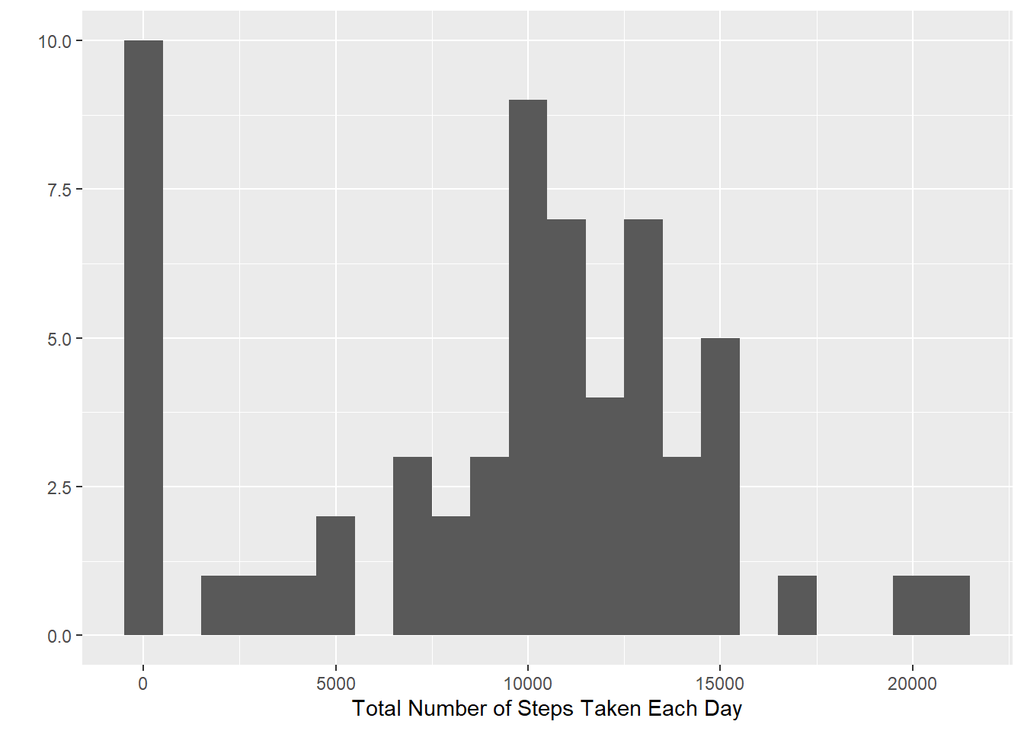

```r
library(ggplot2)

# Calculate total steps taken each day
total.steps <- tapply(data$steps, data$date, FUN=sum, na.rm=TRUE)

# Create a histogram of total steps per day
qplot(total.steps, binwidth=1000, xlab="Total Number of Steps Taken Each Day")
```

```r
# Calculate mean and median of total steps
mean(total.steps, na.rm=TRUE)
```

```
## [1] 9354.23
```

```r
median(total.steps, na.rm=TRUE)
```

```
## [1] 10395
```

## 4. Average Daily Activity Pattern

Next, we examine the average number of steps taken during each 5-minute interval across all days. This will help us understand the general activity pattern.

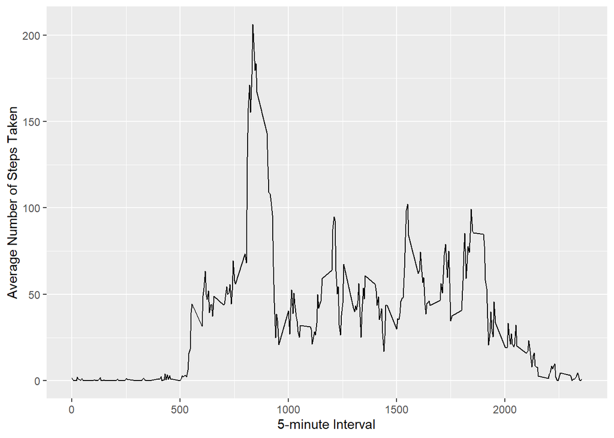

```r
# Calculate the average number of steps for each 5-minute interval
averages <- aggregate(x=list(steps=data$steps), by=list(interval=data$interval),
                      FUN=mean, na.rm=TRUE)

# Plot the average activity pattern over time
ggplot(data=averages, aes(x=interval, y=steps)) +
    geom_line() +
    xlab("5-minute Interval") +
    ylab("Average Number of Steps Taken")
```

To identify the time period with the highest activity, we find the interval with the maximum number of average steps.

```r
# Find the 5-minute interval with the maximum number of steps
averages[which.max(averages$steps),]
```

```
##     interval    steps
## 104      835 206.1698
```

## 5. Handling Missing Data

The dataset contains missing values (coded as `NA`). We will address these by imputing the missing step counts with the average value for each 5-minute interval. This ensures that we do not introduce bias due to missing data.

```r
# Identify missing values in the dataset
missing <- is.na(data$steps)

# Count the number of missing values
table(missing)
```

```
## missing
## FALSE  TRUE
## 15264  2304
```

We then define a function to replace each missing step count with the corresponding interval’s average steps.

```r
# Function to impute missing steps with the mean value for the 5-minute interval
fill.value <- function(steps, interval) {
    filled <- NA
    if (!is.na(steps))
        filled <- c(steps)
    else
        filled <- (averages[averages$interval==interval, "steps"])
    return(filled)
}

# Apply the function to fill missing values in the dataset
filled.data <- data
filled.data$steps <- mapply(fill.value, filled.data$steps, filled.data$interval)
```

### Total Steps After Imputation

Now, let’s compute the total steps taken per day using the filled data and visualize the results with a histogram. We also calculate the mean and median of the total steps after imputing the missing values.

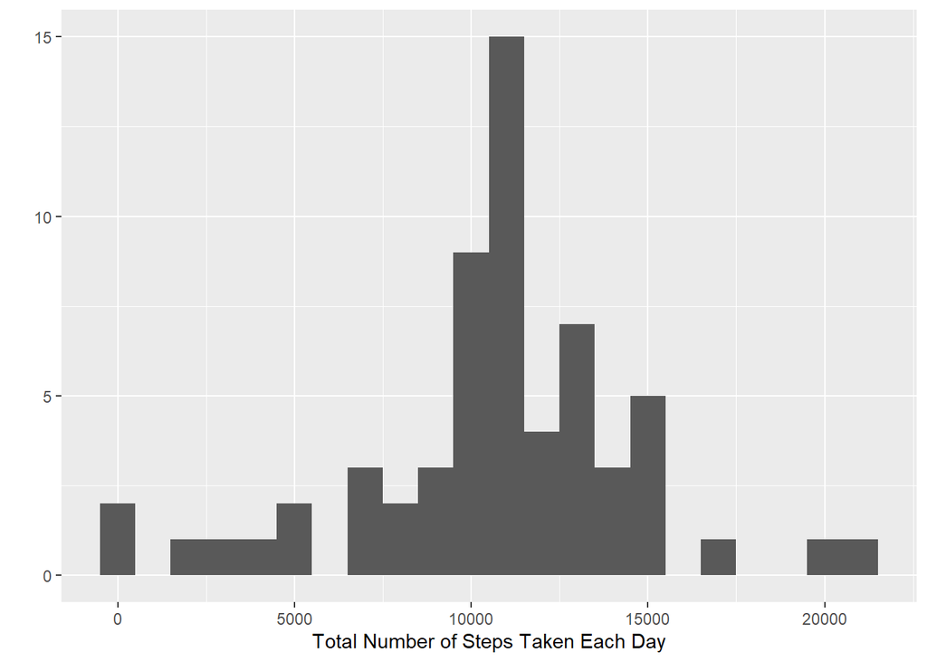

```r
# Calculate total steps taken each day in the filled dataset
total.steps <- tapply(filled.data$steps, filled.data$date, FUN=sum)

# Create a histogram of total steps per day after imputing missing values
qplot(total.steps, binwidth=1000, xlab="Total Number of Steps Taken Each Day")
```

```r
# Calculate mean and median of total steps after imputation
mean(total.steps)
```

```
## [1] 10766.19
```

```r
median(total.steps)
```

```
## [1] 10766.19
```

By imputing missing values, the mean and median steps are higher compared to the original data. This is because days with missing values were initially counted as zero steps, but after imputing, the average steps for those intervals are restored.

## 6. Weekday vs. Weekend Activity Patterns

Finally, we analyze whether there are any differences in activity patterns between weekdays and weekends. We start by classifying each day as a weekday or weekend.

```r
# Function to classify a day as weekday or weekend
weekday.or.weekend <- function(date) {
    day <- weekdays(date)
    if (day %in% c("Monday", "Tuesday", "Wednesday", "Thursday", "Friday"))
        return("weekday")
    else if (day %in% c("Saturday", "Sunday"))
        return("weekend")
    else
        stop("Invalid date")
}

# Convert the 'date' column to Date type and classify each day
filled.data$date <- as.Date(filled.data$date)
filled.data$day <- sapply(filled.data$date, FUN=weekday.or.weekend)
```

We now aggregate the steps by day and interval, and plot the results to compare activity on weekdays and weekends.

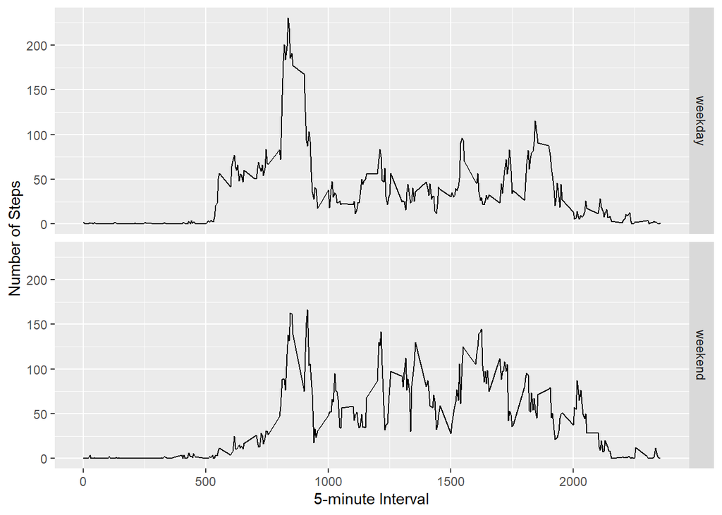

```r
# Aggregate the steps data by interval and day
averages <- aggregate(steps ~ interval + day, data=filled.data, mean)

# Create a panel plot comparing activity on weekdays and weekends
ggplot(averages, aes(interval, steps)) +
    geom_line() +
    facet_grid(day ~ .) +
    xlab("5-minute Interval") +
    ylab("Number of Steps")
```

## 7. Conclusion

Through this analysis, we have examined the total number of steps taken per day, identified the average daily activity patterns, handled missing values, and compared activity patterns between weekdays and weekends. The findings show that weekday and weekend activity patterns differ, and imputing missing data significantly impacts the results by removing zero step days.